# I have used the sample of dataset due to huge size and memory error. Tried using full dataset, but its taking ample time, so will be restricting records to 1,00,000 EN. So will run with 1,00,000 sampl

## 4. Improve Performance of model.

### A. Experiment with other vectorisers.

```python
tfidf_vect = TfidfVectorizer()
X_tfidf_train = tfidf_vect.fit_transform(X_train)
X_tfidf_train.shape
```

```
(75000, 274212)
```

```python
X_tfidf_test = tfidf_vect.transform(X_test)
X_tfidf_test.shape
```

```
(25000, 274212)
```

### B. Build classifier Models using other algorithms than base model.

### C. Tune Parameters/Hyperparameters of the model/s.

### D. Clearly print Performance Metrics.

```python
# split X and y into training and testing sets
X_tfidf_train, X_val, y_train1, y_val = train_test_split(X_tfidf_train,y_train, random_state=random_state,test_size = 0.15,stratify=y_train)
```

```python
# Building model using LGBMClassifier

start = datetime.now()
print("Start Time: ",start)

lgb_base=LGBMClassifier(random_state=random_state, num_leaves=10)
lgb_base.fit(X_tfidf_train,y_train1, eval_set=[(X_val, y_val)])

end = datetime.now()
print("End Time: ",end)
print("Total Time taken in seconds: ",(end - start).total_seconds())
```

```
Start Time:  2023-04-23 18:54:06.524082
[1]	valid_0's multi_logloss: 2.32437
[2]	valid_0's multi_logloss: 2.28114
[3]	valid_0's multi_logloss: 2.30784
[4]	valid_0's multi_logloss: 2.28945
[5]	valid_0's multi_logloss: 2.2959
[6]	valid_0's multi_logloss: 2.29677
[7]	valid_0's multi_logloss: 2.30167
[8]	valid_0's multi_logloss: 2.29555
[9]	valid_0's multi_logloss: 2.30722
[10]	valid_0's multi_logloss: 2.29764
[11]	valid_0's multi_logloss: 2.30037
[12]	valid_0's multi_logloss: 2.29134
[13]	valid_0's multi_logloss: 2.31128
[14]	valid_0's multi_logloss: 2.29664
[15]	valid_0's multi_logloss: 2.32532
[16]	valid_0's multi_logloss: 2.30323
[17]	valid_0's multi_logloss: 2.33441
[18]	valid_0's multi_logloss: 2.31975
[19]	valid_0's multi_logloss: 2.30518
[20]	valid_0's multi_logloss: 2.31303
[21]	valid_0's multi_logloss: 2.34002
[22]	valid_0's multi_logloss: 2.3068
[23]	valid_0's multi_logloss: 2.3268
[24]	valid_0's multi_logloss: 2.32356
[25]	valid_0's multi_logloss: 2.30742
[26]	valid_0's multi_logloss: 2.32977
[27]	valid_0's multi_logloss: 2.44305
[28]	valid_0's multi_logloss: 2.48254
[29]	valid_0's multi_logloss: 2.44042
[30]	valid_0's multi_logloss: 2.49807
[31]	valid_0's multi_logloss: 2.47053
[32]	valid_0's multi_logloss: 2.54739
[33]	valid_0's multi_logloss: 2.55312
[34]	valid_0's multi_logloss: 2.50776
[35]	valid_0's multi_logloss: 2.52089
[36]	valid_0's multi_logloss: 2.46579
[37]	valid_0's multi_logloss: 2.5773
[38]	valid_0's multi_logloss: 2.50999
[39]	valid_0's multi_logloss: 2.51219
```

[output cut: 48 more lines]

```
[88]	valid_0's multi_logloss: 3.26743
[89]	valid_0's multi_logloss: 3.31586
[90]	valid_0's multi_logloss: 3.38579
[91]	valid_0's multi_logloss: 3.32478
[92]	valid_0's multi_logloss: 3.35532
[93]	valid_0's multi_logloss: 3.48353
[94]	valid_0's multi_logloss: 3.46497
[95]	valid_0's multi_logloss: 3.44053
[96]	valid_0's multi_logloss: 3.47722
[97]	valid_0's multi_logloss: 3.50929
[98]	valid_0's multi_logloss: 3.52715
[99]	valid_0's multi_logloss: 3.50933
[100]	valid_0's multi_logloss: 3.54384
End Time:  2023-04-23 19:02:10.243180
Total Time taken in seconds:  483.719098
```

```
Train Accuracy Score: 0.4391529411764706
Test Accuracy Score: 0.36092

Classification Matrix:
               precision    recall  f1-score   support

           0       0.15      0.09      0.11       145
           1       0.17      0.02      0.04       164
           2       0.02      0.04      0.03        52
           3       0.01      0.02      0.01        53
           4       0.31      0.04      0.07      1198
           5       0.01      0.02      0.01        46
           6       0.00      0.00      0.00       143
           7       0.04      0.02      0.03        82
           8       0.10      0.02      0.04       165
```

[output cut: 35 more lines]

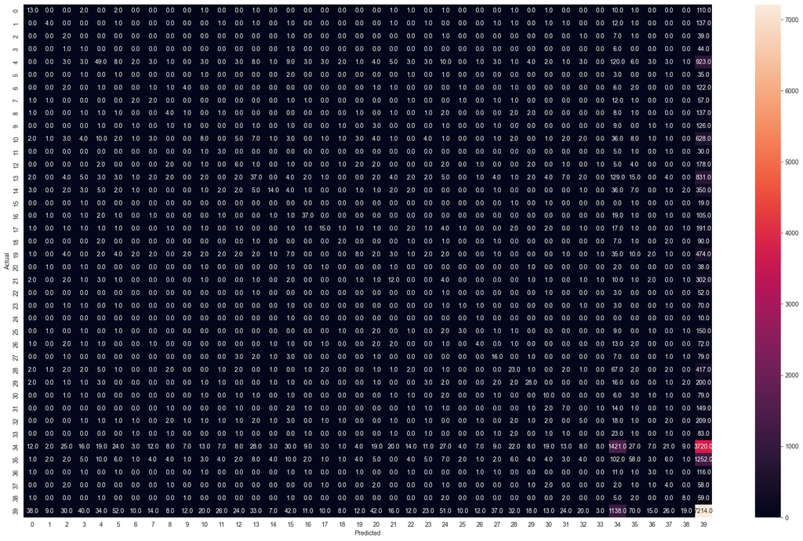

```python
metrics_score(y_test, lgb_base.predict(X_tfidf_test), y_train1, lgb_base.predict(X_tfidf_train), 'LGBMClassifier', model_list)
```

```python
pd.DataFrame(model_list,columns=['Model','Train_Accuracy','Test_Accuracy','Precision','Recall','F1 Score']).sort_values(by=['Recall','F1 Score'], ascending=False)
```

|  | Model | Train_Accuracy | Test_Accuracy | Precision | Recall | F1 Score |
| --- | --- | --- | --- | --- | --- | --- |
| 1 | LGBMClassifier | 0.439153 | 0.36092 | 0.36092 | 0.36092 | 0.36092 |
| 0 | DecisionTreeClassifier | 0.725933 | 0.32536 | 0.32536 | 0.32536 | 0.32536 |

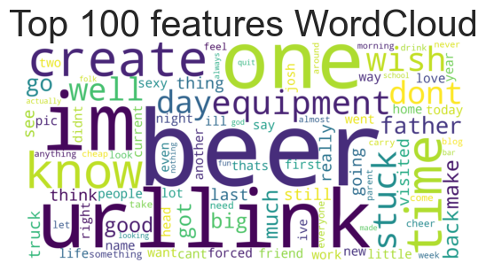

```python
# TF-IDF and ML model Wordloud
get_top_n_words(lgb_base,tfidf_vect.get_feature_names())
```

```python
start = datetime.now()
print("Start Time: ",start)

lgb_tuned=LGBMClassifier(random_state=random_state, num_leaves=31, max_depth=-1,n_estimators=100,learning_rate=0.05)

lgb_tuned.fit(X_tfidf_train,y_train1, eval_set=[(X_val, y_val)])

end = datetime.now()
print("End Time: ",end)
print("Total Time taken in seconds: ",(end - start).total_seconds())
```

```
Start Time:  2023-04-23 19:47:13.388916
[1]	valid_0's multi_logloss: 2.27222
[2]	valid_0's multi_logloss: 2.25882
[3]	valid_0's multi_logloss: 2.24989
[4]	valid_0's multi_logloss: 2.24278
[5]	valid_0's multi_logloss: 2.23641
[6]	valid_0's multi_logloss: 2.23126
[7]	valid_0's multi_logloss: 2.22715
[8]	valid_0's multi_logloss: 2.22386
[9]	valid_0's multi_logloss: 2.22076
[10]	valid_0's multi_logloss: 2.21718
[11]	valid_0's multi_logloss: 2.21352
[12]	valid_0's multi_logloss: 2.21067
[13]	valid_0's multi_logloss: 2.2081
[14]	valid_0's multi_logloss: 2.20587
[15]	valid_0's multi_logloss: 2.20334
[16]	valid_0's multi_logloss: 2.2008
[17]	valid_0's multi_logloss: 2.19883
[18]	valid_0's multi_logloss: 2.19706
[19]	valid_0's multi_logloss: 2.19544
[20]	valid_0's multi_logloss: 2.19369
[21]	valid_0's multi_logloss: 2.19215
[22]	valid_0's multi_logloss: 2.19058
[23]	valid_0's multi_logloss: 2.18913
[24]	valid_0's multi_logloss: 2.18792
[25]	valid_0's multi_logloss: 2.18706
[26]	valid_0's multi_logloss: 2.18609
[27]	valid_0's multi_logloss: 2.18536
[28]	valid_0's multi_logloss: 2.18407
[29]	valid_0's multi_logloss: 2.18339
[30]	valid_0's multi_logloss: 2.18208
[31]	valid_0's multi_logloss: 2.18117
[32]	valid_0's multi_logloss: 2.18041
[33]	valid_0's multi_logloss: 2.17988
[34]	valid_0's multi_logloss: 2.17938
[35]	valid_0's multi_logloss: 2.179
[36]	valid_0's multi_logloss: 2.1785
[37]	valid_0's multi_logloss: 2.17759
[38]	valid_0's multi_logloss: 2.17697
[39]	valid_0's multi_logloss: 2.17646
```

[output cut: 48 more lines]

```
[88]	valid_0's multi_logloss: 2.17613
[89]	valid_0's multi_logloss: 2.1765
[90]	valid_0's multi_logloss: 2.17704
[91]	valid_0's multi_logloss: 2.17729
[92]	valid_0's multi_logloss: 2.17746
[93]	valid_0's multi_logloss: 2.17772
[94]	valid_0's multi_logloss: 2.17802
[95]	valid_0's multi_logloss: 2.17843
[96]	valid_0's multi_logloss: 2.17876
[97]	valid_0's multi_logloss: 2.17925
[98]	valid_0's multi_logloss: 2.17958
[99]	valid_0's multi_logloss: 2.17999
[100]	valid_0's multi_logloss: 2.18043
End Time:  2023-04-23 20:07:26.295521
Total Time taken in seconds:  1212.906605
```

```
Train Accuracy Score: 0.5780235294117647
Test Accuracy Score: 0.4018

Classification Matrix:
               precision    recall  f1-score   support

           0       0.32      0.06      0.09       145
           1       0.33      0.01      0.02       164
           2       0.00      0.00      0.00        52
           3       0.00      0.00      0.00        53
           4       0.76      0.05      0.10      1198
           5       0.25      0.02      0.04        46
           6       0.07      0.01      0.01       143
           7       0.33      0.01      0.02        82
           8       0.33      0.02      0.05       165
```

[output cut: 35 more lines]

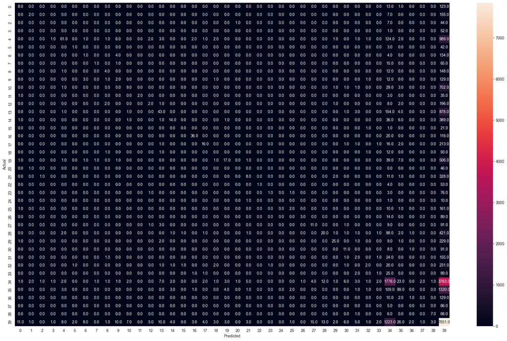

```python
metrics_score(y_test, lgb_tuned.predict(X_tfidf_test), y_train1, lgb_tuned.predict(X_tfidf_train), 'LGBMClassifier_Tuned', model_list)
```

```python
pd.DataFrame(model_list,columns=['Model','Train_Accuracy','Test_Accuracy','Precision','Recall','F1 Score']).sort_values(by=['Recall','F1 Score'], ascending=False)
```

|  | Model | Train_Accuracy | Test_Accuracy | Precision | Recall | F1 Score |
| --- | --- | --- | --- | --- | --- | --- |
| 2 | LGBMClassifier_Tuned | 0.578024 | 0.40180 | 0.40180 | 0.40180 | 0.40180 |
| 1 | LGBMClassifier | 0.439153 | 0.36092 | 0.36092 | 0.36092 | 0.36092 |
| 0 | DecisionTreeClassifier | 0.725933 | 0.32536 | 0.32536 | 0.32536 | 0.32536 |

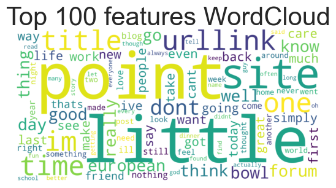

```python
# TF-IDF and ML model Wordloud
get_top_n_words(lgb_tuned,tfidf_vect.get_feature_names())
```

## 5. Share insights on relative performance comparison

### A. Which vectorizer performed better? Probable reason?

### B. Which model outperformed? Probable reason?

### C. Which parameter/hyperparameter significantly helped to improve performance?Probable reason?

### D. According to you, which performance metric should be given most importance, why?

As per the above analysis TF-IDF vectorizer performed better, as TF-IDF not only focuses on the frequency of words present in the corpus but also provides the importance of the words. In above dataset we have many entries where vectorization has been performed using TF-IDF and BOW, and can be seen in WordCloud how it has been interpreted.

```python
get_top_n_words(lgb_tuned,tfidf_vect.get_feature_names())
```

[output not shown]

```python
pd.DataFrame(model_list,columns=['Model','Train_Accuracy','Test_Accuracy','Precision','Recall','F1 Score']).sort_values(by=['Recall','F1 Score'], ascending=False)
```

[output not shown]

From above models, LGBMClassifier has performed good in compare to other models as per the different scores, like accuracy_score, recall, precision, f1 score, and more.

In this block, F1-Score and Recall has been given higher precedence. F1-score provides class-wise performance which helps to improve the model and prediction much better.

$$ F1 Score = \frac{2 * Precision * Recall}{Precision + Recall} $$$$ Recall = \frac{TP}{TP + FN} $$$$ Precision = \frac{TP}{TP + FP} $$

###### #

# Part-B

###### #

## 1. Start chat session with greetings and ask what the user is looking for.

## 2. Accept dynamic text based questions from the user. Reply with relevant answer from the designed corpus.

## 3. End the chat session only if the user requests to end else ask what the user is looking for. Loop continues till the user asks to end it.

```python
corpus=pd.read_json("GL Bot.json")
corpus
```

|  | intents |
| --- | --- |
| 0 | {'tag': 'Intro', 'patterns': ['hi', 'how are y... |
| 1 | {'tag': 'Exit', 'patterns': ['thank you', 'tha... |
| 2 | {'tag': 'Olympus', 'patterns': ['olympus', 'ex... |
| 3 | {'tag': 'SL', 'patterns': ['i am not able to u... |
| 4 | {'tag': 'NN', 'patterns': ['what is deep learn... |
| 5 | {'tag': 'Bot', 'patterns': ['what is your name... |
| 6 | {'tag': 'Profane', 'patterns': ['what the hell... |
| 7 | {'tag': 'Ticket', 'patterns': ['my problem is ... |

Sample JSON have 8 intents with different tags, patterns, responses and context_set.

Different tags are 'Intro', 'Exit', 'Olympus', 'SL', 'NN', 'Bot', 'Profane' and 'Ticket'.

```python
# Checking sample tag
corpus.iloc[0]['intents']
```

```
{'tag': 'Intro',
 'patterns': ['hi',
  'how are you',
  'is anyone there',
  'hello',
  'whats up',
  'hey',
  'yo',
  'listen',
  'please help me',
  'i am learner from',
  'i belong to',
  'aiml batch',
  'aifl batch',
  'i am from',
  'my pm is',
  'blended',
  'online',
  'i am from',
  'hey ya',
  'talking to you for first time'],
 'responses': ['Hello! how can i help you ?'],
 'context_set': ''}
```

```python
def pre_process_over_text(text):

    remove_punc_dict = dict((ord(punc), None) for punc in string.punctuation)
    # Lowercase all textual data
    text = text.lower().translate(remove_punc_dict)

    # Remove all extra white spaces
    text = re.sub(r'\s+', " ", text).strip()

    #tokenize data
    text = word_tokenize(text)

    text = [spell(word) for word in text]

    # lemmatize the data
    text = [lm.lemmatize(word) for word in text]

    return ' '.join(text)
```

```python
X=[]
y=[]
tag_resp_dict=dict()
for intent in corpus['intents'].values:
    tag_resp_dict[intent['tag'].lower()]=intent['responses']
    for pattern in intent['patterns']:
        X.append(pre_process_over_text(pattern))
        y.append(intent['tag'].lower())
len(X),len(y)
```

```
(128, 128)
```

```python
# fit and transforming into vectors from the text data
X=tf_cb.fit_transform(X).toarray()

# label encoding
y=le.fit_transform(y)
label_mapping=le.classes_
```

```python
svc=SVC(random_state=42,C=10,gamma=0.1,kernel='rbf')
svc.fit(X,y)
```

```
SVC(C=10, gamma=0.1, random_state=42)
```

```python
def chat():
    flag=True
    print(emojize("BOT:robot_face:: Hello:wave:, My name is ZhangZetsu.",language='alias'))
    sleep(0.5)
    while flag:
        user_response = input()
        print(emojize(f"YOU:information_desk_person:: {user_response}",language='alias'))
        if user_response is None or len(user_response.strip())==0:
            print(emojize("BOT:robot_face:: Please enter details!!!",language='alias'))
            sleep(0.5)
            continue
        pred = label_mapping[svc.predict(tf_cb.transform([pre_process_over_text(user_response)]).toarray())][0]
        if pred == 'exit':
            flag = False
        print(emojize("BOT:robot_face::",language='alias'),np.random.choice(tag_resp_dict.get(pred)))
        sleep(0.5)
```

```python
chat()
```

```
BOT🤖: Hello👋, My name is ZhangZetsu.
YOU💁: hey
BOT🤖: Hello! how can i help you ?
YOU💁: Please tell me about olympus
BOT🤖: Link: Olympus wiki
YOU💁: Do you know about Supervised Learning
BOT🤖: Link: Machine Learning wiki
YOU💁: What is network and deep
BOT🤖: Link: Neural Nets wiki
YOU💁: thanks
BOT🤖: I hope I was able to assist you, Good Bye
```